# Lab2Diesel

Ayleen Rubio 19003

6/8/2021

# Laboratorio 2: sección de Diesel

## Consumo

```
##        Date    Diesel
## 1   2000-01  634667.1
## 2   2000-02  642380.7
## 3   2000-03  699807.2
## 4   2000-04  586804.0
## 5   2000-05  656948.2
## 6   2000-06  570919.9
## 7   2000-07  576436.0
## 8   2000-08  593770.8
## 9   2000-09  590145.4
## 10  2000-10  641113.4
## 11  2000-11  657086.3
## 12  2000-12  673282.3
## 13  2001-01  569328.8
## 14  2001-02  597749.8
```

[output cut: 243 more lines]

```r
start(datosC.ts)
```

```
## [1] 2001    1
```

```r
end(datosC.ts)
```

```
## [1] 2022    5
```

```r
start(train)
```

```
## [1] 2001    1
```

```r
end(train)
```

```
## [1] 2015   12
```

```r
start(h)
```

```
## [1] 1 1
```

```r
end(h)
```

```
## [1] 1 1
```

```r
frequency(datosC.ts)
```

```
## [1] 12
```

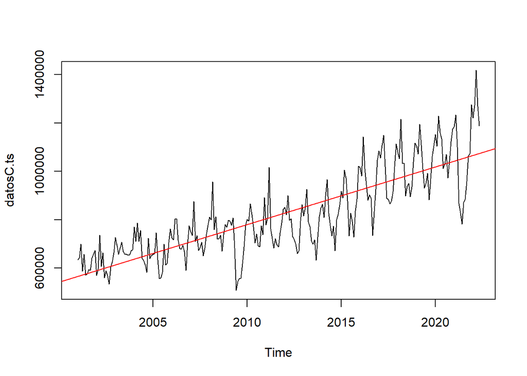

```r
plot(datosC.ts)
abline(reg=lm(datosC.ts~time(datosC.ts)), col=c("red"))
```

Al no mantenerse constante a lo largo del tiempo, se puede decir que esta es una serie no estacionaria en cuanto a la media ya que tiene una tendencia creciente y tampoco es estacionaria respecto a la varianza, ya que hay varios puntos en los que la varianza puede tanto disminuir como aumentar, no se mantiene constante.

Ahora, al descomponer la serie de tiempo, obtenemos lo siguiente:

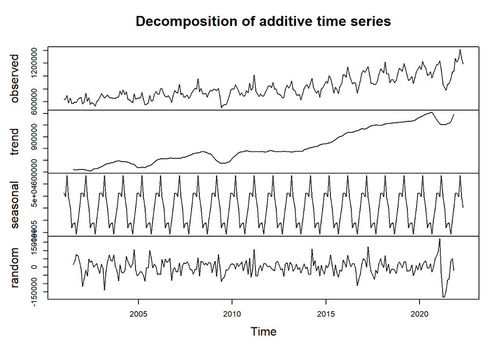

```r
dec.cdec <- decompose(datosC.ts)
plot(dec.cdec)
```

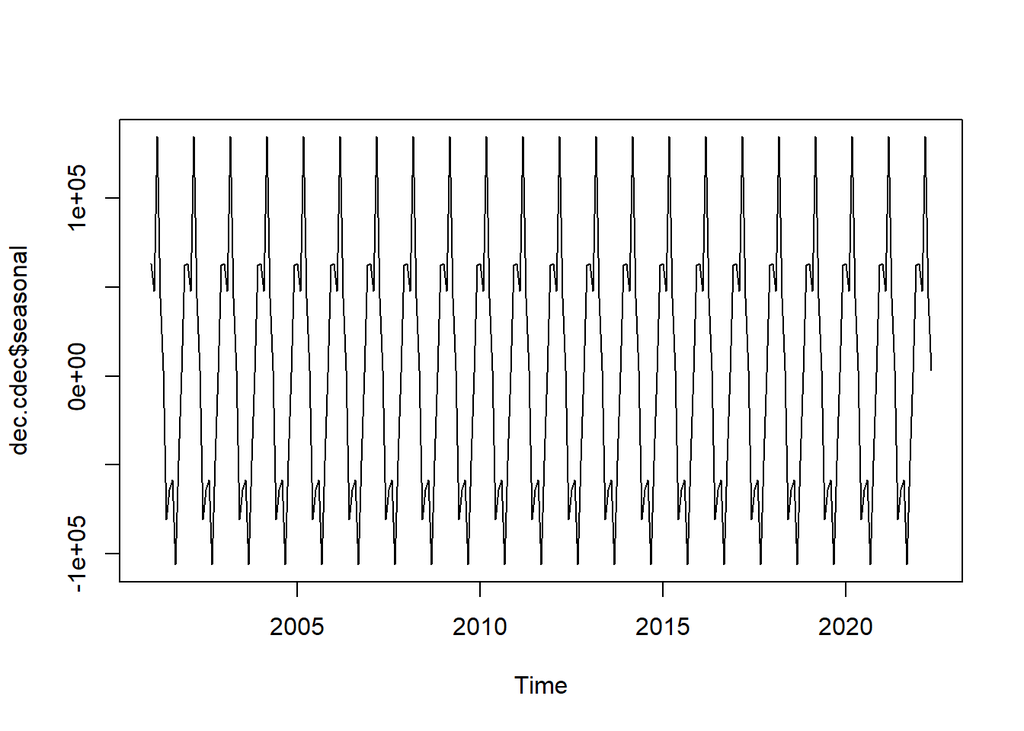

```r
plot(dec.cdec$seasonal)
```

En los componentes podemos observar cómo es que, de hecho, no se tiene tendencia en la media, ya que se tiene una tendencia creciente. En cuanto a la varianza, puede observarse que esta no se mantiene constante, hay varianzas más pequeñas y otras más grandes, sin embargo, esto se podrá comprobar con coeficientes de correlación. En cuanto a estacionalidad, parece que sí tiene ya que el mismo patrón se repite constantemente. Podemos concluir finalmente que nuestra serie no es estacionaria, por lo que es necesario transformarla para poder predecir con ella.

## Estimar los parámetros del modelo

Debido a que no es estacionaria en varianza, primero es necesario aplicar transformación logarítmica con la serie de entrenamiento:

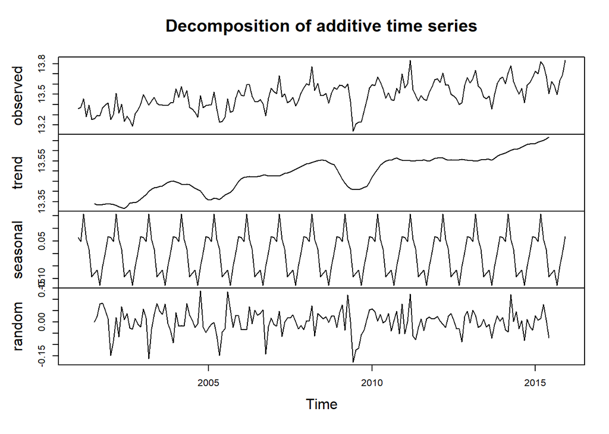

```r
logConsumoTrain <- log(train)
lambda <- BoxCox.lambda(train)
boxcoxTrain <-BoxCox(train, lambda)
plot(decompose(logConsumoTrain))
```

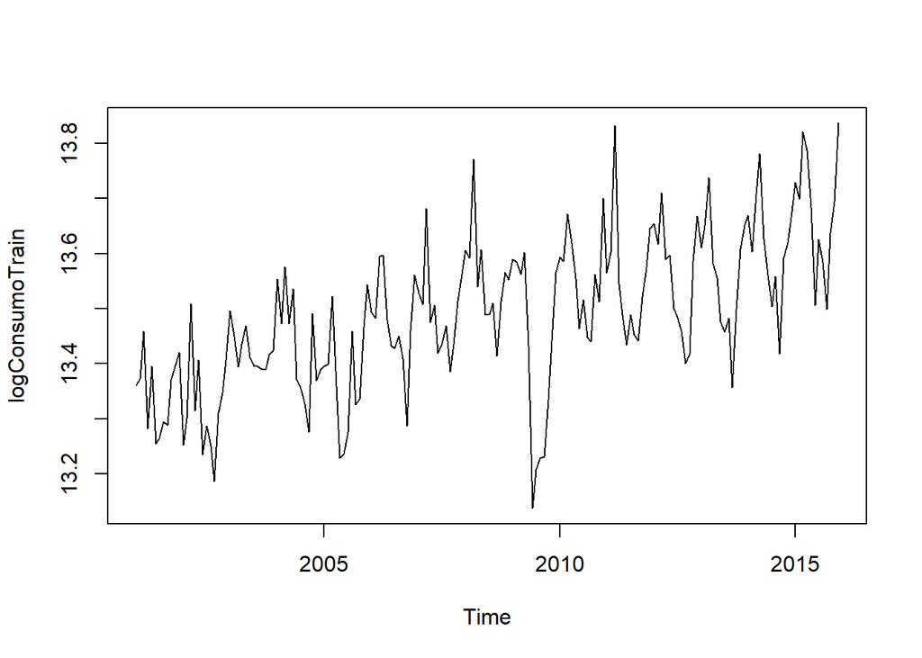

```r
plot(logConsumoTrain)
```

Con esto se ha logrado que la varianza sea más constante, ahora es necesario verificar la estacionariedad en media. Es necesario verificar la existencia de raices unitarias, si se cuenta con ellas, esto quiere decir que no es estacionaria en media y hay que aplicar procesos de diferenciación.

```r
adfTest(train)
```

```
##
## Title:
##  Augmented Dickey-Fuller Test
##
## Test Results:
##   PARAMETER:
##     Lag Order: 1
##   STATISTIC:
##     Dickey-Fuller: 0.0133
##   P VALUE:
##     0.6191
##
## Description:
##  Sat Aug 07 00:52:13 2021 by user: Ingebor Rubio
```

```r
unitrootTest(train)
```

```
##
## Title:
##  Augmented Dickey-Fuller Test
##
## Test Results:
##   PARAMETER:
##     Lag Order: 1
##   STATISTIC:
##     DF: 0.0133
##   P VALUE:
##     t: 0.6857
##     n: 0.6846
##
## Description:
##  Sat Aug 07 00:52:13 2021 by user: Ingebor Rubio
```

En ambas pruebas puede observarse un valor mayor a 0.05 por lo que no es posible rechazar la hipótesis nula planteada, la cual indica que hay una ausencia de raices unitarias, lo cual significa que no es estacionaria en media. Aplicaremos una diferenciación para poder rechazar el hecho de que existan reices unitarias y que así nuestra serie de tiempo sea estacionaria en media.

```r
trainDiff <-diff(logConsumoTrain)
adfTest(diff(train))
```

```
##
## Title:
##  Augmented Dickey-Fuller Test
##
## Test Results:
##   PARAMETER:
##     Lag Order: 1
##   STATISTIC:
##     Dickey-Fuller: -10.8165
##   P VALUE:
##     0.01
##
## Description:
##  Sat Aug 07 00:52:13 2021 by user: Ingebor Rubio
```

En esta prueba el valor p es menor que 0.05 por lo que ahora sí es posible rechazar la hipótesis nula y luego de una diferenciación, la serie de tiempo ya es estacionaria en media, esto quiere decir que d=1. Ahora para identificar los valores tanto de p como de q podemos utilizar los gráficos de autocorrelación y autocorrelación parcial.

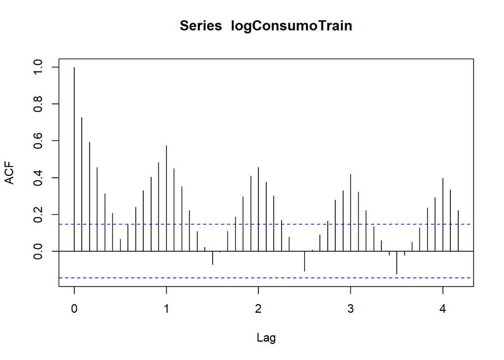

```r
acf(logConsumoTrain,50)
```

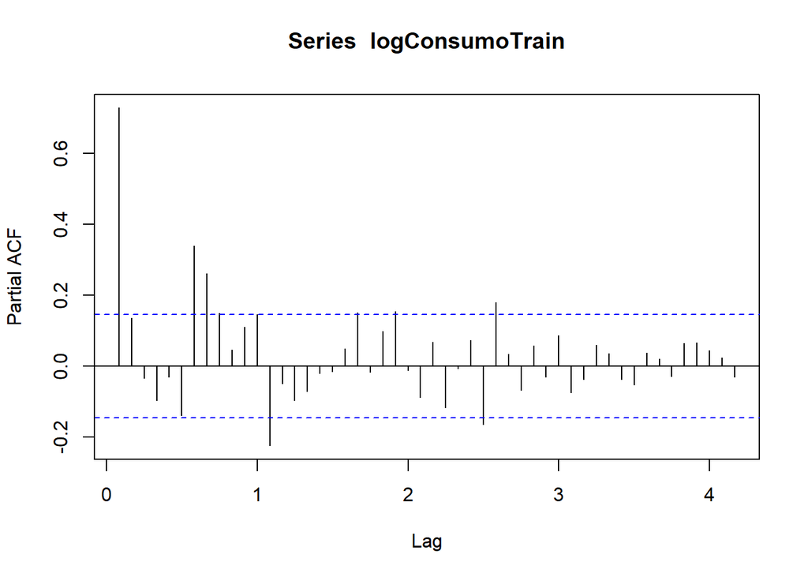

```r
pacf(logConsumoTrain,50)
```

A continuación observaremos estacionalidad:

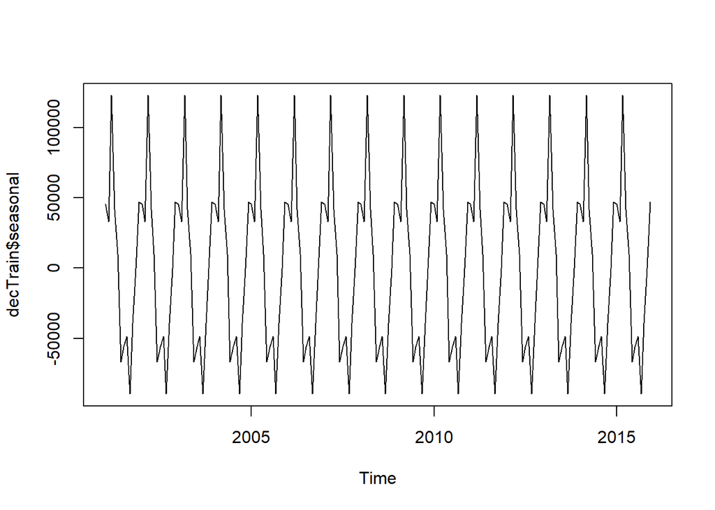

```r
decTrain <- decompose(train)
plot(decTrain$seasonal)
```

Sí se cuenta con estacinalidad como puede observarse y para poder comprender este comportamiento se harán las funciones de autocorrelación y autocorrelación parcial con 36 resagos para determinar en qué momentos son los picos estacinales.

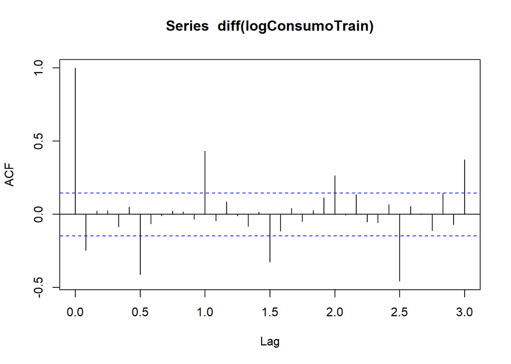

```r
acf(diff(logConsumoTrain),36)
```

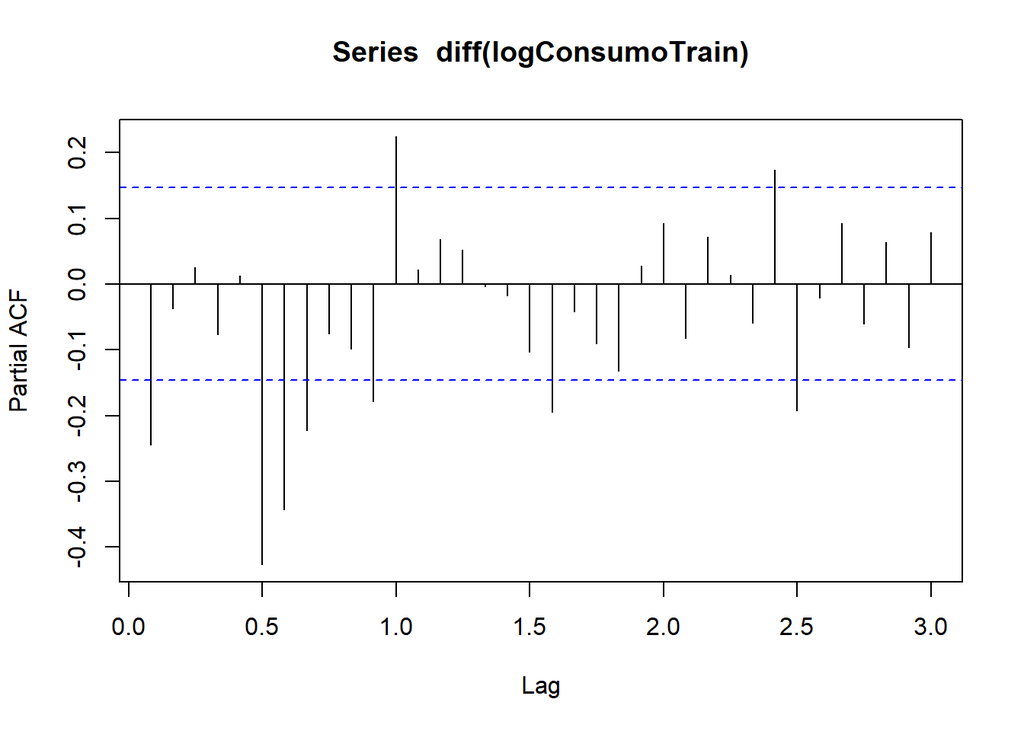

```r
pacf(diff(logConsumoTrain),36)
```

En la función de autocorrelación tenemos picos estacionales en 1, 2 y 3, en el caso de la autocorrelación parcial tenemos un pico significativo en 1. Con esto podemos inferir que los parámetros del componente estacional son P, D = 1 y Q = 0.

```r
fitArima <- arima(logConsumoTrain,order=c(1,1,1),seasonal=c(1,1,0))
```

Es posible que R genere un modelo automático teniendo en cuenta los parámetros de la serie:

```r
fitAutoArima <- auto.arima(train)
```

## Significacion de los coeficientes

Para poder verificar que tan significativos son los coeficientes de los modelos se puede hacer la siguiente prueba:

```r
coeftest(fitArima)
```

```
##
## z test of coefficients:
##
##       Estimate Std. Error z value  Pr(>|z|)
## ar1   0.029732   0.127942  0.2324    0.8162
## ma1  -0.622916   0.101417 -6.1421 8.143e-10 ***
## sar1 -0.457452   0.070313 -6.5059 7.721e-11 ***
## ---
## Signif. codes:  0 '***' 0.001 '**' 0.01 '*' 0.05 '.' 0.1 ' ' 1
```

Dos de los coeficientes son significativos.

```r
coeftest(fitAutoArima)
```

```
##
## z test of coefficients:
##
##          Estimate  Std. Error z value Pr(>|z|)
## ar1      0.039265    0.466852  0.0841  0.93297
## ar2      0.234527    0.196425  1.1940  0.23249
## ar3      0.236400    0.096497  2.4498  0.01429 *
## ma1      0.304981    0.486953  0.6263  0.53111
## sar1    -0.580746    0.647235 -0.8973  0.36957
## sma1    -0.213714    0.634149 -0.3370  0.73611
## sma2    -0.512648    0.513760 -0.9978  0.31836
## drift 1337.959304  218.015839  6.1370 8.41e-10 ***
## ---
## Signif. codes:  0 '***' 0.001 '**' 0.01 '*' 0.05 '.' 0.1 ' ' 1
```

con el modelo generado automáticamente, dos coeficientes son significativos.

## Análisis de residuales

Es necesario que los residuos no estén correlacionados entre sí y que se distributan normalmente, analizando esto con el modelo fitArima:

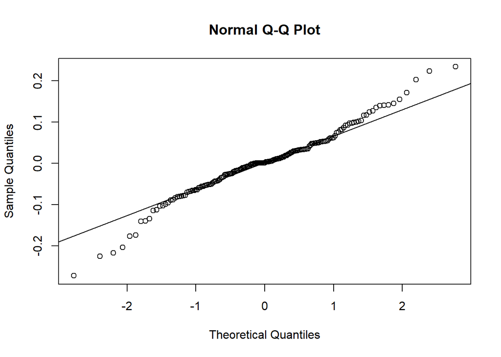

```r
qqnorm(fitArima$residuals)
qqline(fitArima$residuals)
```

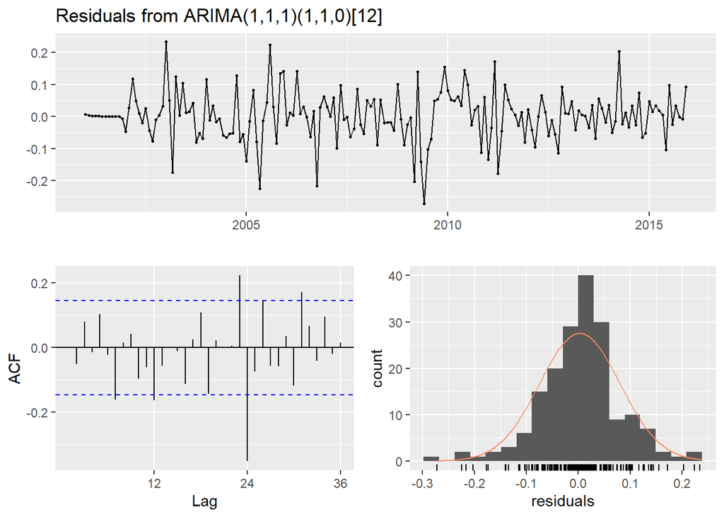

```
##
##  Ljung-Box test
##
## data:  Residuals from ARIMA(1,1,1)(1,1,0)[12]
## Q* = 63.139, df = 21, p-value = 4.229e-06
##
## Model df: 3.   Total lags used: 24
```

```r
checkresiduals(fitArima)
```

Ahora, utilizando el modelo generado automáticamente por R:

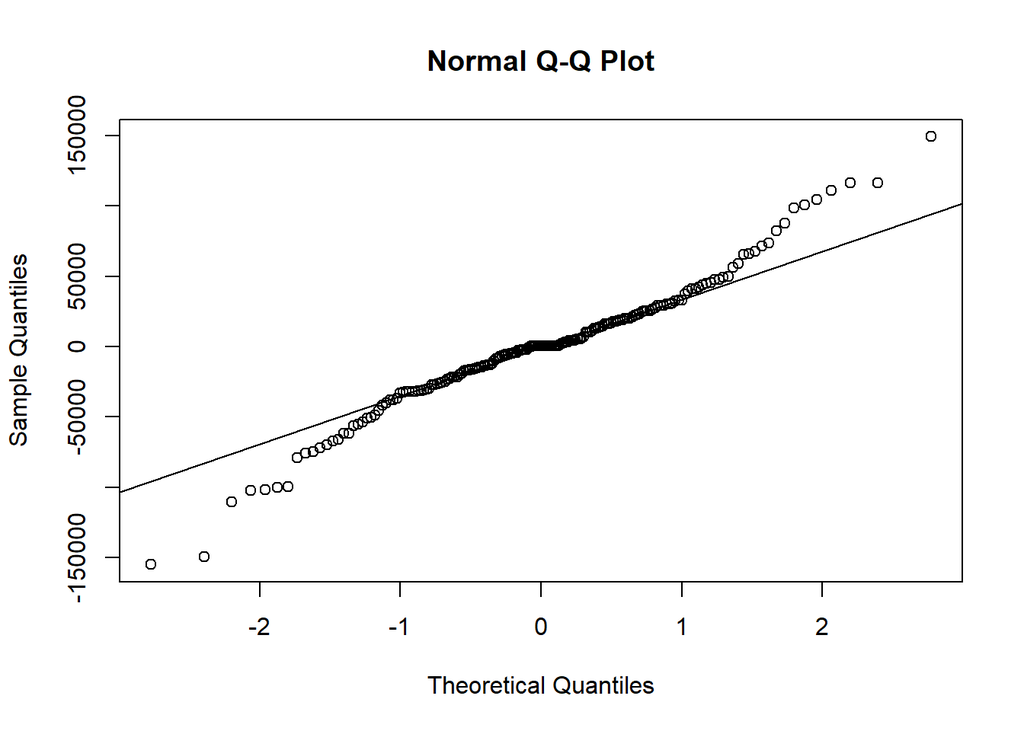

```r
qqnorm(fitAutoArima$residuals)
qqline(fitAutoArima$residuals)
```

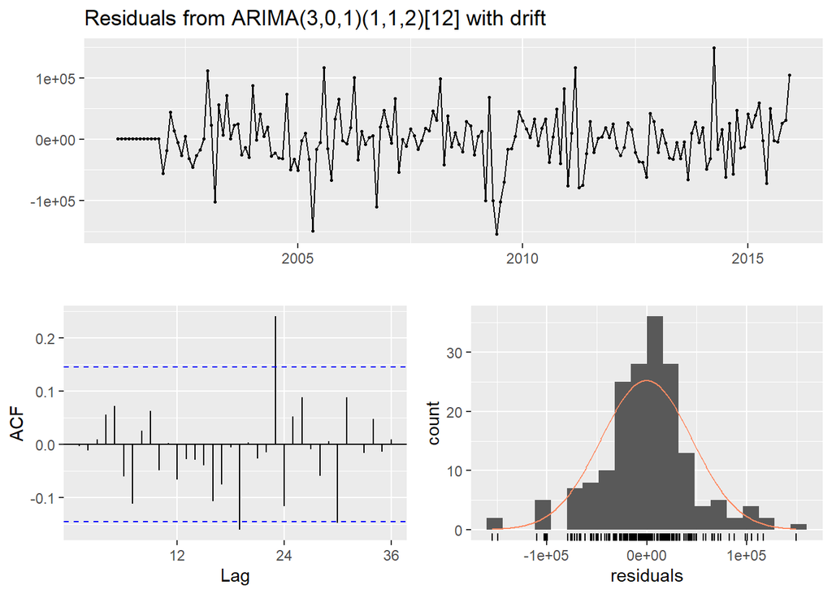

```
##
##  Ljung-Box test
##
## data:  Residuals from ARIMA(3,0,1)(1,1,2)[12] with drift
## Q* = 31.396, df = 16, p-value = 0.01197
##
## Model df: 8.   Total lags used: 24
```

```r
checkresiduals(fitAutoArima)
```

Debido a que ninguno de los dos modelos es aceptable para predecir, no se han podido utilizar.

## Prophet

Se ha intentado instalar prophet, sin embargo, se cuenta con el siguiente error: Error: package or namespace load failed for ‘prophet’ in .doLoadActions(where, attach): error in load action .__A__.1 for package prophet: Rcpp::loadModule(module = “stan_fit4prophet_mod”, what = TRUE, : Unable to load module “stan_fit4prophet_mod”: el paquete ‘Rcpp_precious_remove’ no ofrece la función ‘Rcpp’

por lo que la predicción por este medio tampoco es posible

## Importación

```r
dataImportacion <- read.csv("DatosImportacionCombustibles.csv")
datosImportacion <- dataImportacion[,c(2,3,7,8)]

datosImportacion$Date <- with(datosImportacion, sprintf("%d-%02d", Anio, Mes))
datosImportacion <- datosImportacion[,c(3,4,5)]

datosI <- within(datosImportacion, {
  Diesel = ifelse(is.na(Diesel),DieselLS,Diesel)
})
datosI <- datosI[,c(3,1)]

datosI.ts <- ts(datosI$Diesel,start = c(2001,1),frequency=12)

train <- head(datosI.ts, round(length(datosI.ts) *0.7))
h<- length(datosI.ts)-length(train)
test <- tail(datosI.ts,h)

start(datosI.ts)
```

```
## [1] 2001    1
```

```r
end(datosI.ts)
```

```
## [1] 2021    5
```

```r
start(train)
```

```
## [1] 2001    1
```

```r
end(train)
```

```
## [1] 2015    4
```

```r
start(h)
```

```
## [1] 1 1
```

```r
end(h)
```

```
## [1] 1 1
```

```r
frequency(datosI.ts)
```

```
## [1] 12
```

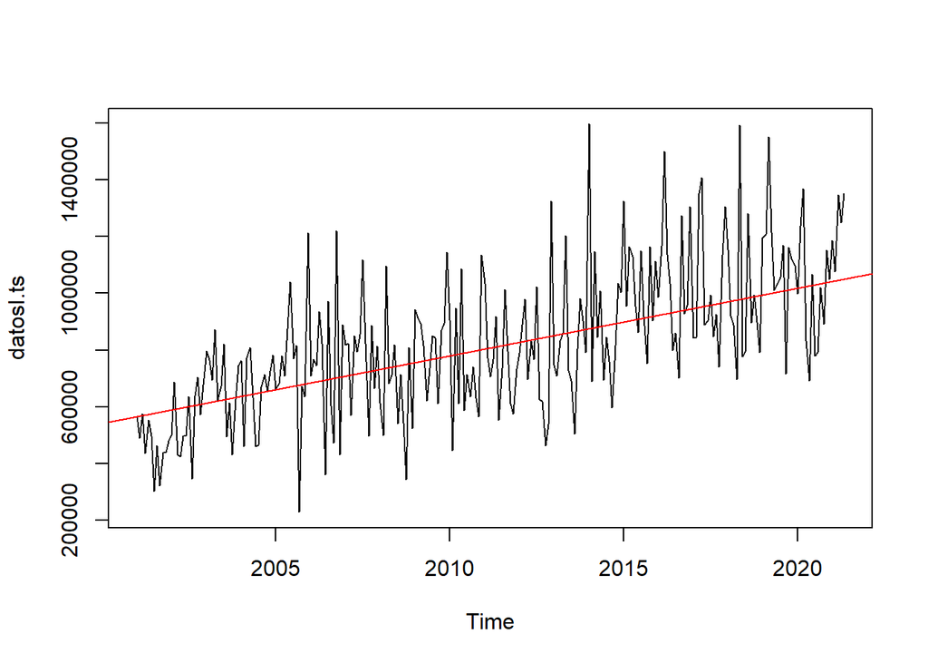

```r
plot(datosI.ts)
abline(reg=lm(datosC.ts~time(datosC.ts)), col=c("red"))
```

La serie de tiempo comienza en enero de 2001, termina en mayo de 2021 y tiene una frecuencia de 12, ya que los datos se tienen según los 12 meses de cada año. A simple vista puede observarse que, a pesar de tener altos y bajos, la importación de combustible ha ido aumentando siguiendo una tendencia a lo largo de los años, teniendo picos tanto altos como bajos.

Al no mantenerse constante a lo largo del tiempo, se puede decir que esta es una serie no estacionaria en cuanto a la media ya que tiene una tendencia creciente y tampoco es estacionaria respecto a la varianza, ya que hay varios puntos en los que la varianza puede tanto disminuir como aumentar, no se mantiene constante.

Ahora, al descomponer la serie de tiempo, obtenemos lo siguiente:

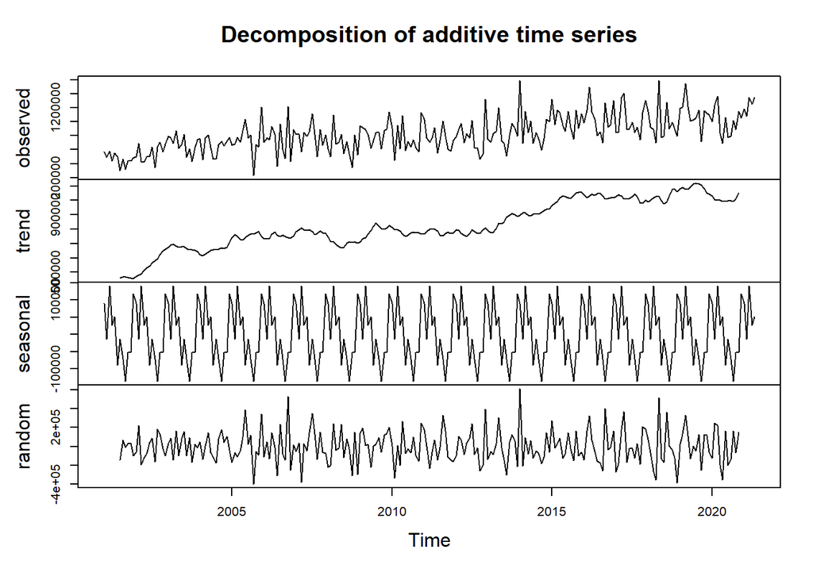

```r
dec.idec <- decompose(datosI.ts)
plot(dec.idec)
```

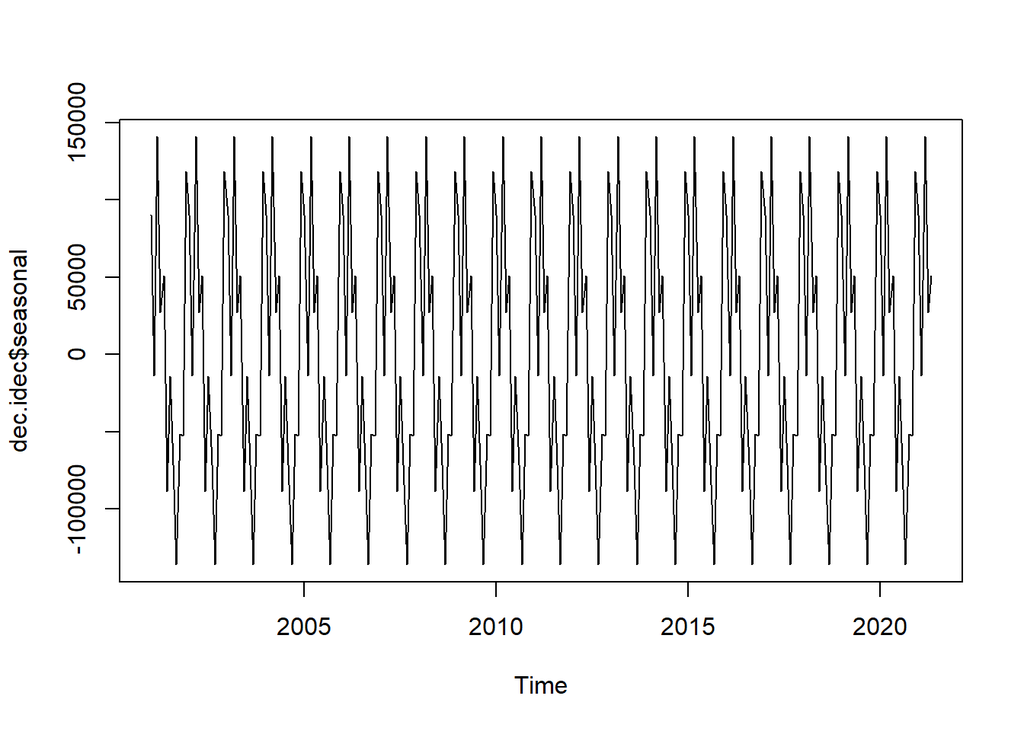

```r
plot(dec.idec$seasonal)
```

En los componentes podemos observar cómo es que, de hecho, no se tiene tendencia en la media, ya que se tiene una tendencia creciente. En cuanto a la varianza, puede observarse que esta no se mantiene constante, hay varianzas más pequeñas y otras más grandes, sin embargo, esto se podrá comprobar con coeficientes de correlación. En cuanto a estacionalidad, parece que sí tiene ya que el mismo patrón se repite constantemente. Podemos concluir finalmente que nuestra serie no es estacionaria, por lo que es necesario transformarla para poder predecir con ella.

## Estimar los parámetros del modelo

Debido a que no es estacionaria en varianza, primero es necesario aplicar transformación logarítmica con la serie de entrenamiento:

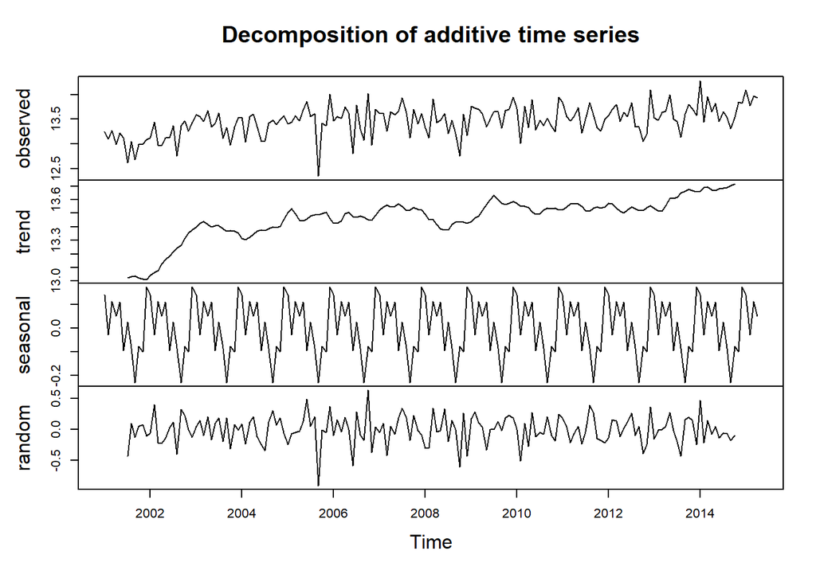

```r
logiTrain <- log(train)
lambda <- BoxCox.lambda(train)
boxcoxTrain <-BoxCox(train, lambda)
plot(decompose(logiTrain))
```

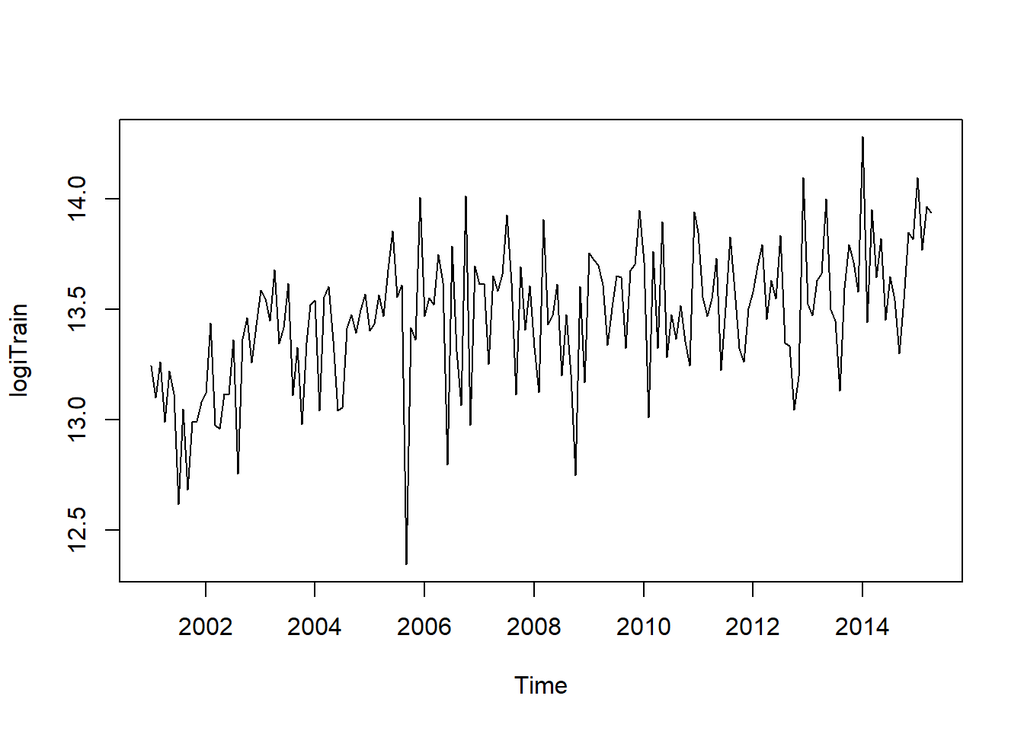

```r
plot(logiTrain)
```

Con esto se ha logrado que la varianza sea más constante, ahora es necesario verificar la estacionariedad en media. Es necesario verificar la existencia de raices unitarias, si se cuenta con ellas, esto quiere decir que no es estacionaria en media y hay que aplicar procesos de diferenciación.

```r
adfTest(train)
```

```
##
## Title:
##  Augmented Dickey-Fuller Test
##
## Test Results:
##   PARAMETER:
##     Lag Order: 1
##   STATISTIC:
##     Dickey-Fuller: -0.9005
##   P VALUE:
##     0.3276
##
## Description:
##  Sat Aug 07 00:52:19 2021 by user: Ingebor Rubio
```

```r
unitrootTest(train)
```

```
##
## Title:
##  Augmented Dickey-Fuller Test
##
## Test Results:
##   PARAMETER:
##     Lag Order: 1
##   STATISTIC:
##     DF: -0.9005
##   P VALUE:
##     t: 0.3248
##     n: 0.4892
##
## Description:
##  Sat Aug 07 00:52:19 2021 by user: Ingebor Rubio
```

En ambas pruebas puede observarse un valor mayor a 0.05 por lo que no es posible rechazar la hipótesis nula planteada, la cual indica que hay una ausencia de raices unitarias, lo cual significa que no es estacionaria en media. Aplicaremos una diferenciación para poder rechazar el hecho de que existan reices unitarias y que así nuestra serie de tiempo sea estacionaria en media.

```r
trainDiff <-diff(logiTrain)
adfTest(diff(train))
```

```
##
## Title:
##  Augmented Dickey-Fuller Test
##
## Test Results:
##   PARAMETER:
##     Lag Order: 1
##   STATISTIC:
##     Dickey-Fuller: -15.2594
##   P VALUE:
##     0.01
##
## Description:
##  Sat Aug 07 00:52:20 2021 by user: Ingebor Rubio
```

En esta prueba el valor p es menor que 0.05 por lo que ahora sí es posible rechazar la hipótesis nula y luego de una diferenciación, la serie de tiempo ya es estacionaria en media, esto quiere decir que d=1. Ahora para identificar los valores tanto de p como de q podemos utilizar los gráficos de autocorrelación y autocorrelación parcial.

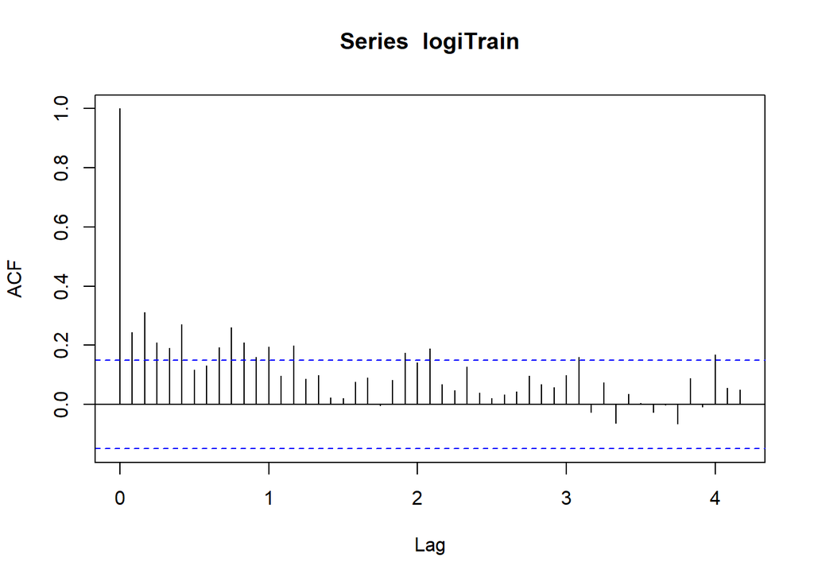

```r
acf(logiTrain,50)
```

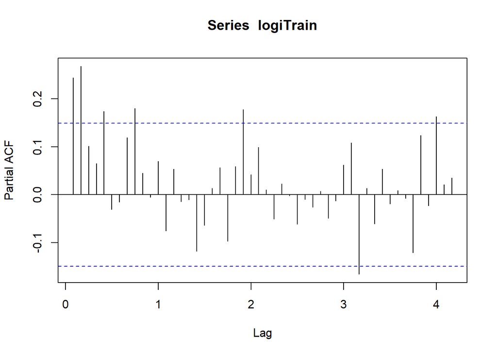

```r
pacf(logiTrain,50)
```

A continuación observaremos estacionalidad:

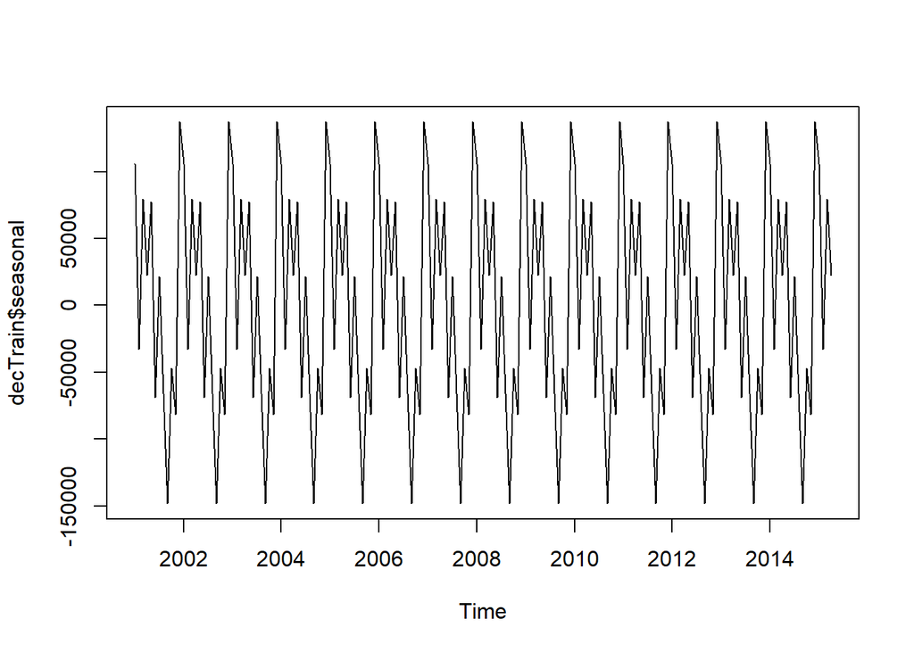

```r
decTrain <- decompose(train)
plot(decTrain$seasonal)
```

Sí se cuenta con estacinalidad como puede observarse y para poder comprender este comportamiento se harán las funciones de autocorrelación y autocorrelación parcial con 36 resagos para determinar en qué momentos son los picos estacinales.

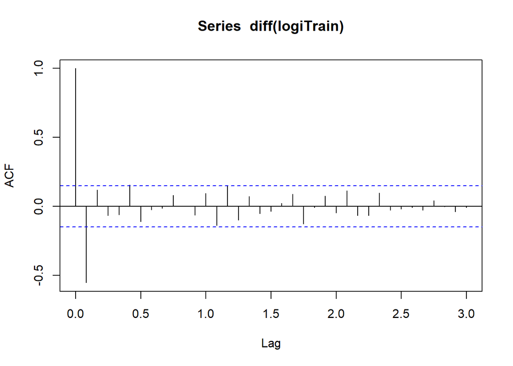

```r
acf(diff(logiTrain),36)
```

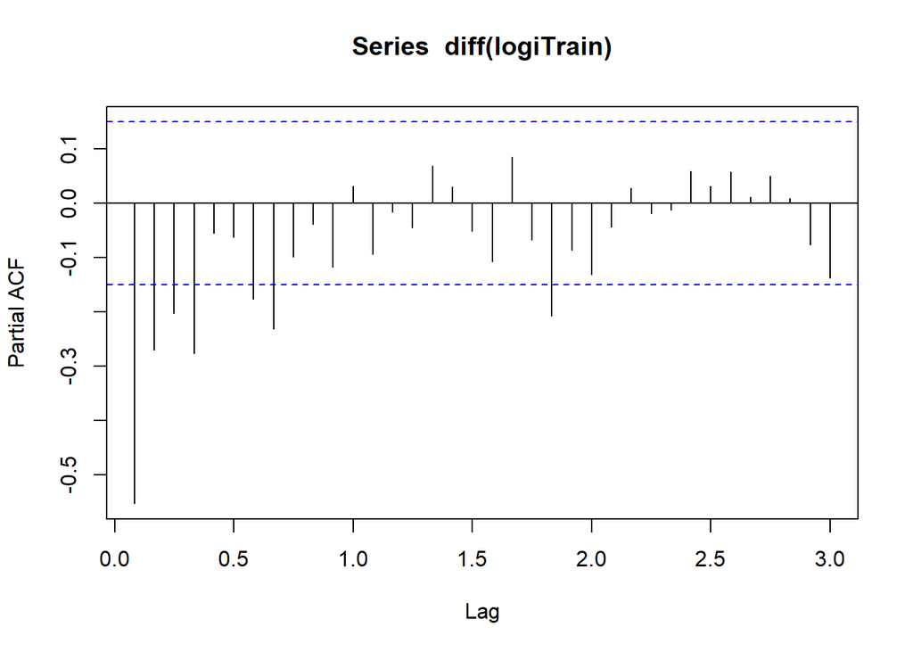

```r
pacf(diff(logiTrain),36)
```

EN la función de autocorrelación no tenemos picos estacionales, en el caso de la autocorrelación parcial tampoco los tenemos. Con esto podemos inferir que los parámetros del componente estacional son P, D y Q = 0.

```r
fitArima <- arima(logiTrain,order=c(3,1,1),seasonal=c(0,0,0))
```

Es posible que R genere un modelo automático teniendo en cuenta los parámetros de la serie:

```r
fitAutoArima <- auto.arima(train)
```

## Significacion de los coeficientes

Para poder verificar que tan significativos son los coeficientes de los modelos se puede hacer la siguiente prueba:

```r
coeftest(fitArima)
```

```
##
## z test of coefficients:
##
##      Estimate Std. Error  z value Pr(>|z|)
## ar1 -0.020717   0.085422  -0.2425   0.8084
## ar2  0.082087   0.084727   0.9688   0.3326
## ar3 -0.041707   0.081827  -0.5097   0.6103
## ma1 -0.902714   0.040480 -22.3005   <2e-16 ***
## ---
## Signif. codes:  0 '***' 0.001 '**' 0.01 '*' 0.05 '.' 0.1 ' ' 1
```

En este caso tenemos un coeficiente significativo.

```r
coeftest(fitAutoArima)
```

```
##
## z test of coefficients:
##
##       Estimate Std. Error z value Pr(>|z|)
## ar1  -0.204961   0.604133 -0.3393   0.7344
## ar2   0.052455   0.090187  0.5816   0.5608
## ma1  -0.745911   0.601114 -1.2409   0.2146
## ma2  -0.151309   0.542111 -0.2791   0.7802
## sar1  0.099233   0.079529  1.2478   0.2121
```

Con el modelo generado automáticamente ningún coeficiente es significativo.

## Análisis de residuales

Es necesario que los residuos no estén correlacionados entre sí y que se distributan normalmente, analizando esto con el modelo fitArima:

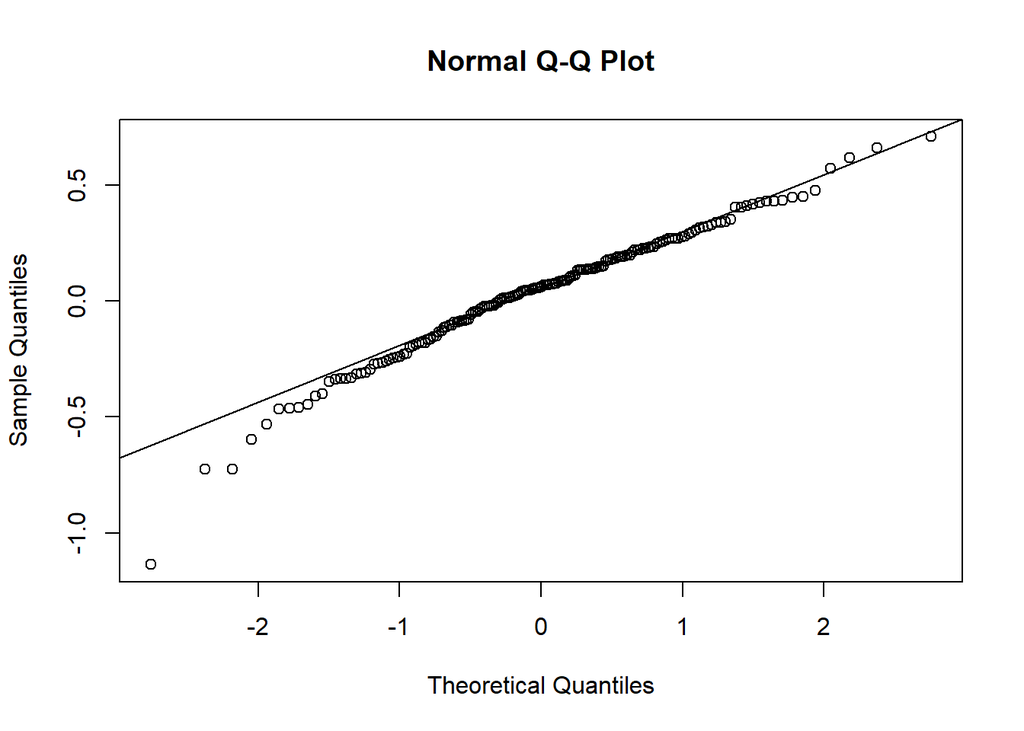

```r
qqnorm(fitArima$residuals)
qqline(fitArima$residuals)
```

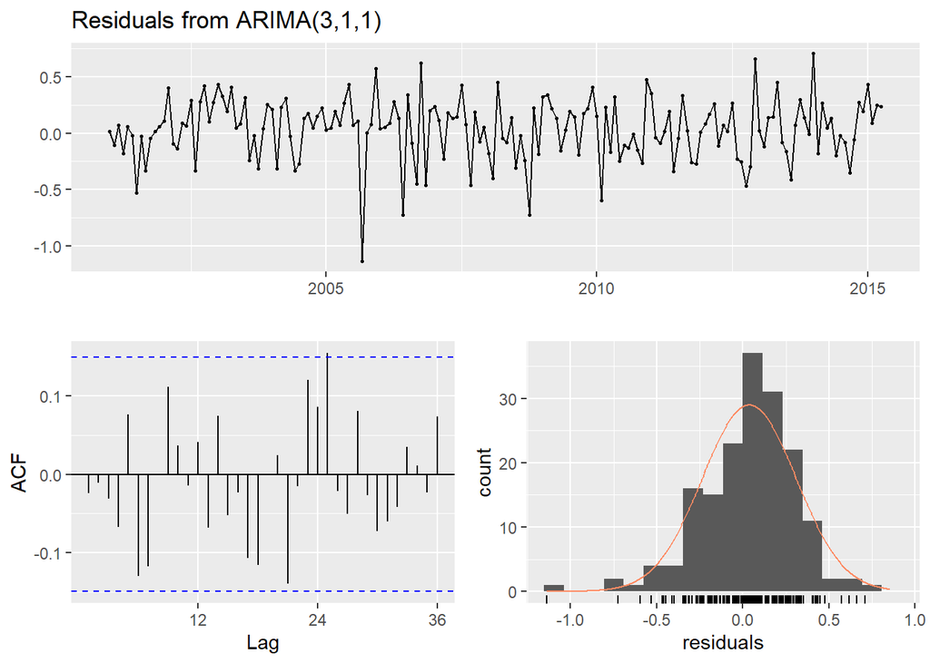

```
##
##  Ljung-Box test
##
## data:  Residuals from ARIMA(3,1,1)
## Q* = 26.428, df = 20, p-value = 0.1521
##
## Model df: 4.   Total lags used: 24
```

```r
checkresiduals(fitArima)
```

Al observar los gráficos obtenidos, los datos aparentan tener una distribución normal respecto a la forma de campana, también puede decirse que no hay correlaciones significativas y según el test de Ljung-Box, tenemos un valor p mayor a 0.05, por lo que los datos se distribuyen de forma independiente, esto quiere decir que no se rechaza la hipótesis nula, esto significa que el modelo generado es aceptable para predecir.

Ahora, utilizando el modelo generado automáticamente por R:

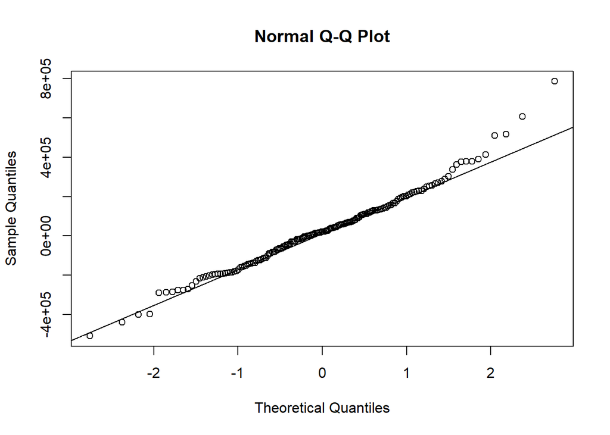

```r
qqnorm(fitAutoArima$residuals)
qqline(fitAutoArima$residuals)
```

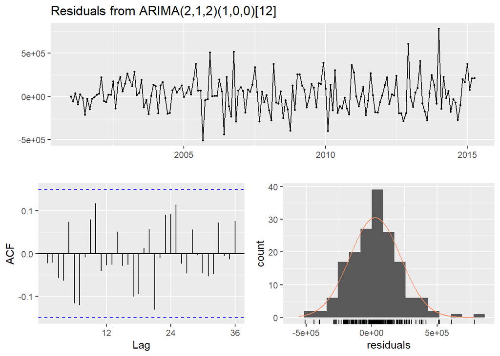

```
##
##  Ljung-Box test
##
## data:  Residuals from ARIMA(2,1,2)(1,0,0)[12]
## Q* = 23.749, df = 19, p-value = 0.206
##
## Model df: 5.   Total lags used: 24
```

```r
checkresiduals(fitAutoArima)
```

En este caso también se cuenta con una distribución normal en cuanto a la forma de campana y no hay correlaciones significativas. En este caso el valor p es mayor a 0.05, por lo que los datos se distribuyen de forma independiente, esto quiere decir que no se rechaza la hipótesis nula, esto significa que el modelo generado es aceptable para predecir.

## Contrastes respecto a modelos alternativos

```r
AIC(fitArima,fitAutoArima)
```

```
##              df        AIC
## fitArima      5   55.85356
## fitAutoArima  6 4667.00624
```

```r
BIC(fitArima, fitAutoArima)
```

```
##              df        BIC
## fitArima      5   71.56188
## fitAutoArima  6 4685.85622
```

Según la información obtenida tanto en AIC y BIC, en ambos casos fitArima tiene un menor valor, por lo que este podría ser mejor para predecir.

## Predicción

Se harán predicciones por medio de forecast usando la misma cantidad de meses que hay en el conjunto de prueba y comparándolo con los valores reales de este mismo conjunto.

```r
#fitArima %>%
#  forecast(h) %>%
#  autoplot() + autolayer(log(test))
```

Se muestra el siguiente error: Error: Invalid input: date_trans works with objects of class Date only

Por lo que la predicción no es posible

## Prophet

Se ha intentado instalar prophet, sin embargo, se cuenta con el siguiente error: Error: package or namespace load failed for ‘prophet’ in .doLoadActions(where, attach): error in load action .__A__.1 for package prophet: Rcpp::loadModule(module = “stan_fit4prophet_mod”, what = TRUE, : Unable to load module “stan_fit4prophet_mod”: el paquete ‘Rcpp_precious_remove’ no ofrece la función ‘Rcpp’

Por lo que la predicción por este medio tampoco es posible